# Ridge Regression using Package caret

Data Mining

Description for Ridge Regression using Package caret

Yeongeun Jeon , Jung In Seo  
2023-08-08

> Ridge Regression의 장점
- 규제항을 통해 회귀계수를 “0”에 가깝게 추정한다.
  - 회귀계수 추정치의 분산을 감소시켜 `Training Dataset`의 변화에도 회귀계수 추정치가 크게 변하지 않는다.

> Ridge Regression의 단점
- $\lambda = \infty$가 아닌 한 회귀계수를 정확하게 “0”으로 추정하지 못한다.
  - 변수 선택을 수행할 수 없다.
- 예측변수가 많을 경우 해석이 어렵다.

> 실습 자료 : 유니버셜 은행의 고객 2,500명에 대한 자료(출처 : Data Mining for Business Intelligence, Shmueli et al. 2010)이며, 총 13개의 변수를 포함하고 있다. 이 자료에서 **Target**은 `Personal Loan`이다.

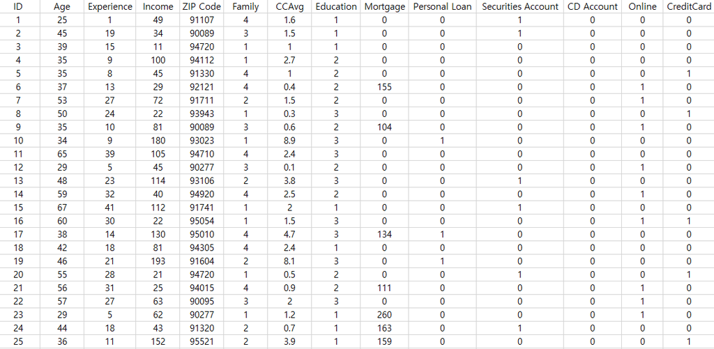

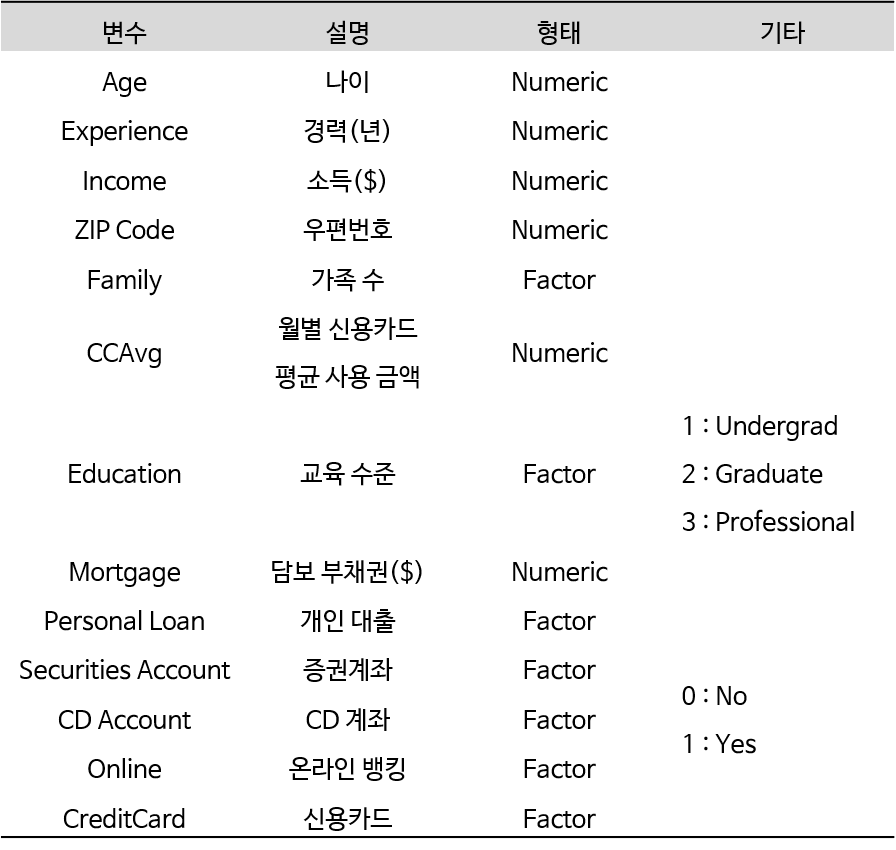

# **1. 데이터 불러오기**

```r
pacman::p_load("data.table",
               "tidyverse",
               "dplyr",
               "ggplot2", "GGally",
               "caret",
               "doParallel", "parallel")                                # For 병렬 처리

registerDoParallel(cores=detectCores())                                 # 사용할 Core 개수 지정

UB <- fread("../Universal Bank_Main.csv")                               # 데이터 불러오기

UB %>%
  as_tibble
```

```
# A tibble: 2,500 × 14
      ID   Age Experience Income `ZIP Code` Family CCAvg Education
   <int> <int>      <int>  <int>      <int>  <int> <dbl>     <int>
 1     1    25          1     49      91107      4   1.6         1
 2     2    45         19     34      90089      3   1.5         1
 3     3    39         15     11      94720      1   1           1
 4     4    35          9    100      94112      1   2.7         2
 5     5    35          8     45      91330      4   1           2
 6     6    37         13     29      92121      4   0.4         2
 7     7    53         27     72      91711      2   1.5         2
 8     8    50         24     22      93943      1   0.3         3
 9     9    35         10     81      90089      3   0.6         2
10    10    34          9    180      93023      1   8.9         3
# ℹ 2,490 more rows
# ℹ 6 more variables: Mortgage <int>, `Personal Loan` <int>,
#   `Securities Account` <int>, `CD Account` <int>, Online <int>,
#   CreditCard <int>
```

# **2. 데이터 전처리**

```r
UB %<>%
  data.frame() %>%                                                      # Data Frame 형태로 변환
  mutate(Personal.Loan = ifelse(Personal.Loan == 1, "yes", "no")) %>%   # Target을 문자형 변수로 변환
  select(-1)                                                            # ID 변수 제거

# Convert to Factor
fac.col <- c("Family", "Education", "Securities.Account",
             "CD.Account", "Online", "CreditCard",
             # Target
             "Personal.Loan")

UB <- UB %>%
  mutate_at(fac.col, as.factor)                                         # 범주형으로 변환

glimpse(UB)                                                             # 데이터 구조 확인
```

```
Rows: 2,500
Columns: 13
$ Age                <int> 25, 45, 39, 35, 35, 37, 53, 50, 35, 34, 6…
$ Experience         <int> 1, 19, 15, 9, 8, 13, 27, 24, 10, 9, 39, 5…
$ Income             <int> 49, 34, 11, 100, 45, 29, 72, 22, 81, 180,…
$ ZIP.Code           <int> 91107, 90089, 94720, 94112, 91330, 92121,…
$ Family             <fct> 4, 3, 1, 1, 4, 4, 2, 1, 3, 1, 4, 3, 2, 4,…
$ CCAvg              <dbl> 1.6, 1.5, 1.0, 2.7, 1.0, 0.4, 1.5, 0.3, 0…
$ Education          <fct> 1, 1, 1, 2, 2, 2, 2, 3, 2, 3, 3, 2, 3, 2,…
$ Mortgage           <int> 0, 0, 0, 0, 0, 155, 0, 0, 104, 0, 0, 0, 0…
$ Personal.Loan      <fct> no, no, no, no, no, no, no, no, no, yes, …
$ Securities.Account <fct> 1, 1, 0, 0, 0, 0, 0, 0, 0, 0, 0, 0, 1, 0,…
$ CD.Account         <fct> 0, 0, 0, 0, 0, 0, 0, 0, 0, 0, 0, 0, 0, 0,…
$ Online             <fct> 0, 0, 0, 0, 0, 1, 1, 0, 1, 0, 0, 1, 0, 1,…
$ CreditCard         <fct> 0, 0, 0, 0, 1, 0, 0, 1, 0, 0, 0, 0, 0, 0,…
```

# **3. 데이터 탐색**

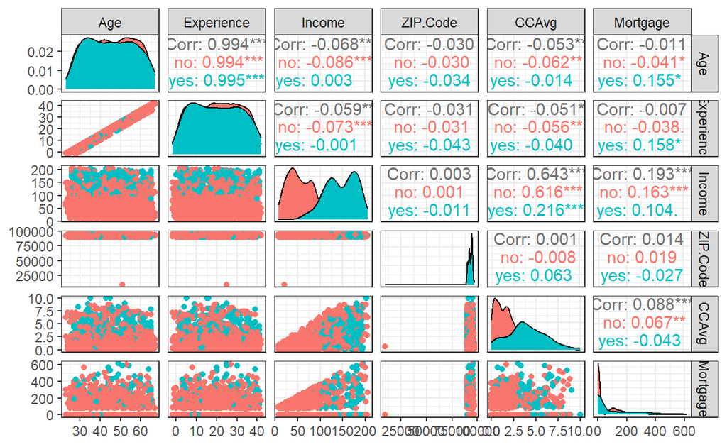

```r
ggpairs(UB,
        columns = c("Age", "Experience", "Income",        # 수치형 예측 변수
                    "ZIP.Code", "CCAvg", "Mortgage"),
        aes(colour = Personal.Loan)) +                    # Target의 범주에 따라 색깔을 다르게 표현
  theme_bw()
```

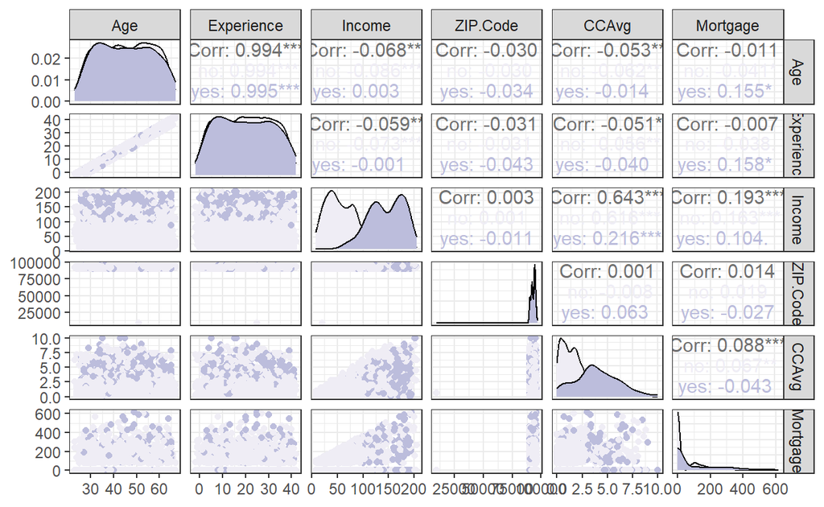

```r
ggpairs(UB,
        columns = c("Age", "Experience", "Income",        # 수치형 예측 변수
                    "ZIP.Code", "CCAvg", "Mortgage"),
        aes(colour = Personal.Loan)) +                    # Target의 범주에 따라 색깔을 다르게 표현
  scale_color_brewer(palette="Purples") +                 # 특정 색깔 지정
  scale_fill_brewer(palette="Purples") +                  # 특정 색깔 지정
  theme_bw()
```

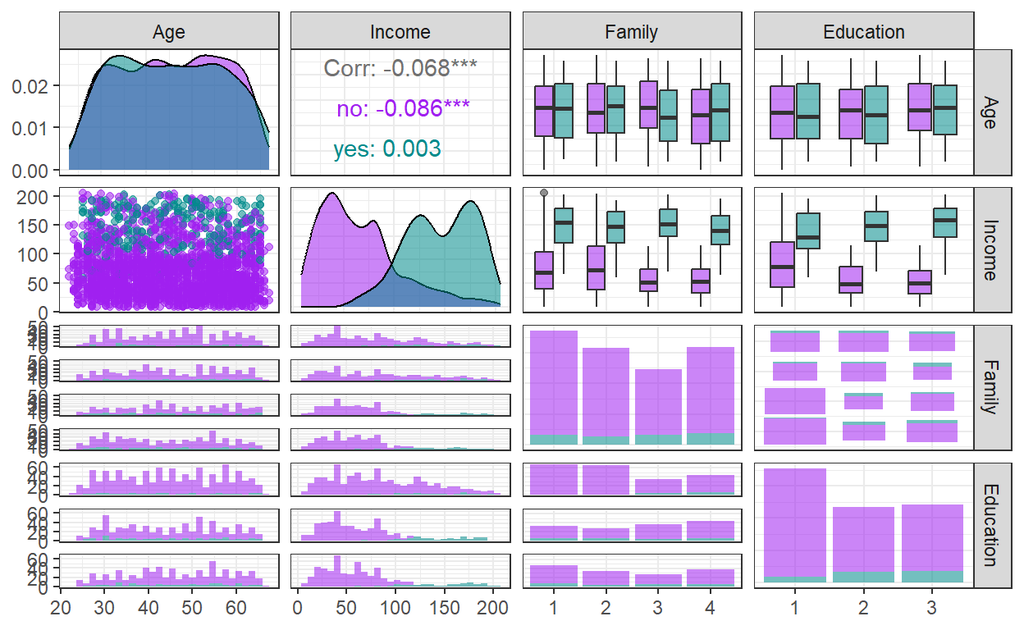

```r
ggpairs(UB,
        columns = c("Age", "Income",                      # 수치형 예측 변수
                    "Family", "Education"),               # 범주형 예측 변수
        aes(colour = Personal.Loan, alpha = 0.8)) +       # Target의 범주에 따라 색깔을 다르게 표현
  scale_colour_manual(values = c("purple","cyan4")) +     # 특정 색깔 지정
  scale_fill_manual(values = c("purple","cyan4")) +       # 특정 색깔 지정
  theme_bw()
```

# **4. 데이터 분할**

```r
# Partition (Training Dataset : Test Dataset = 7:3)
y      <- UB$Personal.Loan                            # Target

set.seed(200)
ind    <- createDataPartition(y, p = 0.7, list = T)   # Index를 이용하여 7:3으로 분할
UB.trd <- UB[ind$Resample1,]                          # Training Dataset
UB.ted <- UB[-ind$Resample1,]                         # Test Dataset
```

# **5. 모형 훈련**

Package `"caret"`은 통합 API를 통해 R로 기계 학습을 실행할 수 있는 매우 실용적인 방법을 제공한다. Package `"caret"`를 통해 `Ridge Regression`을 수행하기 위해 옵션 `method`에 다양한 방법(Ex: `"ridge"`, `"foba"` 등)을 입력할 수 있지만, 대부분 회귀 문제에 대해서만 분석이 가능하다. 분류와 회귀 문제 모두 가능한 `"glmnet"`을 이용하려면 옵션 `tuneGrid = expand.grid()`을 통해 탐색하고자 하는 초모수 `lambda`의 범위를 직접 지정해줘야 한다.

```r
fitControl <- trainControl(method = "cv", number = 5,                 # 5-Fold Cross Validation (5-Fold CV)
                           allowParallel = TRUE)                      # 병렬 처리


set.seed(200)                                                         # For CV
ridge.fit <- train(Personal.Loan ~ ., data = UB.trd,
                   trControl = fitControl ,
                   method = "glmnet",
                   tuneGrid = expand.grid(alpha = 0,                  # For Ridge Regression
                                          lambda = seq(0, 1, 0.001)), # lambda의 탐색 범위
                   preProc = c("center", "scale"))                    # Standardization for 예측 변수

ridge.fit
```

```
glmnet

1751 samples
  12 predictor
   2 classes: 'no', 'yes'

Pre-processing: centered (15), scaled (15)
Resampling: Cross-Validated (5 fold)
Summary of sample sizes: 1401, 1401, 1400, 1401, 1401
Resampling results across tuning parameters:

  lambda  Accuracy   Kappa
  0.000   0.9514530  0.682422731
  0.001   0.9514530  0.682422731
  0.002   0.9514530  0.682422731
  0.003   0.9514530  0.682422731
  0.004   0.9514530  0.682422731
  0.005   0.9514530  0.682422731
  0.006   0.9514530  0.682422731
  0.007   0.9514530  0.682422731
  0.008   0.9514530  0.682422731
  0.009   0.9514530  0.682422731
  0.010   0.9514530  0.682422731
  0.011   0.9514530  0.682422731
  0.012   0.9514530  0.682422731
  0.013   0.9514530  0.682422731
  0.014   0.9514530  0.682422731
  0.015   0.9514530  0.682422731
  0.016   0.9514530  0.682422731
  0.017   0.9503101  0.672562190
  0.018   0.9497387  0.668299630
  0.019   0.9497387  0.668299630
  0.020   0.9491673  0.662855819
  0.021   0.9491673  0.662855819
  0.022   0.9491673  0.662855819
  0.023   0.9485958  0.657234464
  0.024   0.9480244  0.651426737
  0.025   0.9480244  0.651426737
  0.026   0.9474530  0.647042949
  0.027   0.9474530  0.647042949
```

[output cut: 963 more lines]

```
  0.991   0.8972015  0.000000000
  0.992   0.8972015  0.000000000
  0.993   0.8972015  0.000000000
  0.994   0.8972015  0.000000000
  0.995   0.8972015  0.000000000
  0.996   0.8972015  0.000000000
  0.997   0.8972015  0.000000000
  0.998   0.8972015  0.000000000
  0.999   0.8972015  0.000000000
  1.000   0.8972015  0.000000000

Tuning parameter 'alpha' was held constant at a value of 0
Accuracy was used to select the optimal model using the
 largest value.
The final values used for the model were alpha = 0 and lambda = 0.016.
```

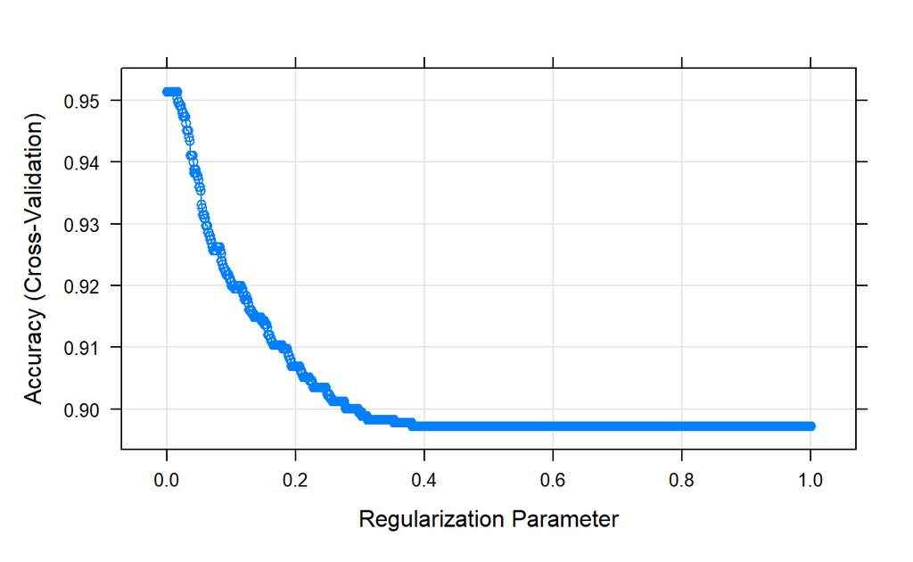

```r
plot(ridge.fit)                                                       # Plot
```

```r
ridge.fit$bestTune                                                    # lambda의 최적값
```

```
   alpha lambda
17     0  0.016
```

`Result!` `lambda` = 0.016일 때 정확도가 가장 높은 것을 알 수 있으며, `lambda` = 0.016를 가지는 모형을 최적의 훈련된 모형으로 선택한다.

```r
round(coef(ridge.fit$finalModel, ridge.fit$bestTune$lambda), 3)       # lambda의 최적값에 대한 회귀계수 추정치
```

```
16 x 1 sparse Matrix of class "dgCMatrix"
                        s1
(Intercept)         -3.311
Age                  0.023
Experience           0.013
Income               1.362
ZIP.Code             0.072
Family2             -0.172
Family3              0.353
Family4              0.339
CCAvg                0.374
Education2           0.632
Education3           0.631
Mortgage             0.087
Securities.Account1 -0.170
CD.Account1          0.615
Online1             -0.057
CreditCard1         -0.286
```

`Result!` 데이터 “UB.trd”의 Target “Personal.Loan”은 “no”와 “yes” 2개의 클래스를 가지며, “Factor” 변환하면 알파벳순으로 수준을 부여하기 때문에 “yes”가 두 번째 클래스가 된다. 즉, “yes”에 속할 확률(= 개인 대출 제의를 수락할 확률)을 $p$라고 할 때, 추정된 회귀계수를 이용하여 다음과 같은 모형식을 얻을 수 있다.
$$\begin{align*}
\log{\frac{p}{1-p}} = &-3.311 +0.023 Z_{\text{Age}} +0.013 Z_{\text{Experience}} + 1.362 Z_{\text{Income}} \\
&+0.072 Z_{\text{ZIP.Code}} -0.172 Z_{\text{Family2}} + 0.353 Z_{\text{Family3}} + 0.339 Z_{\text{Family4}} \\
&+ 0.374 Z_{\text{CCAvg}} + 0.632 Z_{\text{Education2}} + 0.631 Z_{\text{Education3}} + 0.087 Z_{\text{Mortgage}} \\
&-0.170 Z_{\text{Securities.Account1}} + 0.615 Z_{\text{CD.Account1}} -0.057 Z_{\text{Online1}} -0.286 Z_{\text{CreditCard1}}
\end{align*}$$
여기서, $Z_{\text{예측 변수}}$는 표준화한 예측 변수를 의미한다.
범주형 예측 변수(“Family”, “Education”, “Securities.Account”, “CD.Account”, “Online”, “CreditCard”)는 더미 변환이 수행되었는데, 예를 들어, `Family2`는 가족 수가 2명인 경우 “1”값을 가지고 2명이 아니면 “0”값을 가진다.

# **6. 모형 평가**

`Caution!` 모형 평가를 위해 `Test Dataset`에 대한 `예측 class/확률` 이 필요하며, 함수 `predict()`를 이용하여 생성한다.

```r
# 예측 class 생성
test.ridge.class <- predict(ridge.fit,
                            newdata = UB.ted[,-9])     # Test Dataset including Only 예측 변수

test.ridge.class %>%
  as_tibble
```

```
# A tibble: 749 × 1
   value
   <fct>
 1 no
 2 no
 3 no
 4 no
 5 no
 6 no
 7 no
 8 no
 9 no
10 no
# ℹ 739 more rows
```

## **6-1. ConfusionMatrix**

```r
CM   <- caret::confusionMatrix(test.ridge.class, UB.ted$Personal.Loan,
                               positive = "yes")       # confusionMatrix(예측 class, 실제 class, positive = "관심 class")
CM
```

```
Confusion Matrix and Statistics

          Reference
Prediction  no yes
       no  669  38
       yes   4  38

               Accuracy : 0.9439
                 95% CI : (0.925, 0.9593)
    No Information Rate : 0.8985
    P-Value [Acc > NIR] : 6.273e-06

                  Kappa : 0.6164

 Mcnemar's Test P-Value : 3.543e-07

            Sensitivity : 0.50000
            Specificity : 0.99406
         Pos Pred Value : 0.90476
         Neg Pred Value : 0.94625
             Prevalence : 0.10147
         Detection Rate : 0.05073
   Detection Prevalence : 0.05607
      Balanced Accuracy : 0.74703

       'Positive' Class : yes
```

## **6-2. ROC 곡선**

```r
# 예측 확률 생성
test.ridge.prob <- predict(ridge.fit,
                           newdata = UB.ted[,-9],     # Test Dataset including Only 예측 변수
                           type = "prob")             # 예측 확률 생성


test.ridge.prob %>%
  as_tibble
```

```
# A tibble: 749 × 2
      no     yes
   <dbl>   <dbl>
 1 0.993 0.00672
 2 0.978 0.0220
 3 0.994 0.00583
 4 0.997 0.00301
 5 0.976 0.0239
 6 0.986 0.0140
 7 0.952 0.0484
 8 0.886 0.114
 9 0.909 0.0913
10 0.956 0.0438
# ℹ 739 more rows
```

```r
test.ridge.prob <- test.ridge.prob[,2]                 # "Personal.Loan = yes"에 대한 예측 확률

ac  <- UB.ted$Personal.Loan                            # Test Dataset의 실제 class
pp  <- as.numeric(test.ridge.prob)                     # 예측 확률을 수치형으로 변환
```

### **1) Package “pROC”**

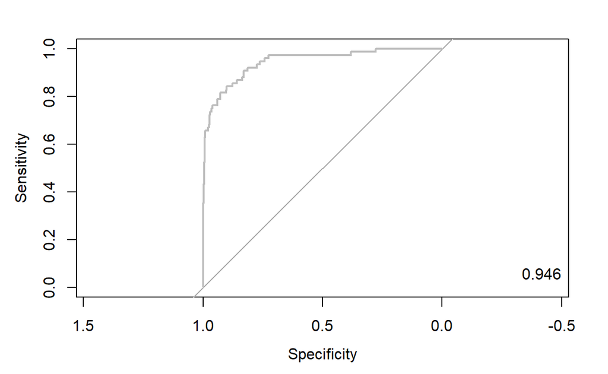

```r
pacman::p_load("pROC")

ridge.roc  <- roc(ac, pp, plot = T, col = "gray")      # roc(실제 class, 예측 확률)
auc        <- round(auc(ridge.roc), 3)
legend("bottomright", legend = auc, bty = "n")
```

`Caution!` Package `"pROC"`를 통해 출력한 ROC 곡선은 다양한 함수를 이용해서 그래프를 수정할 수 있다.

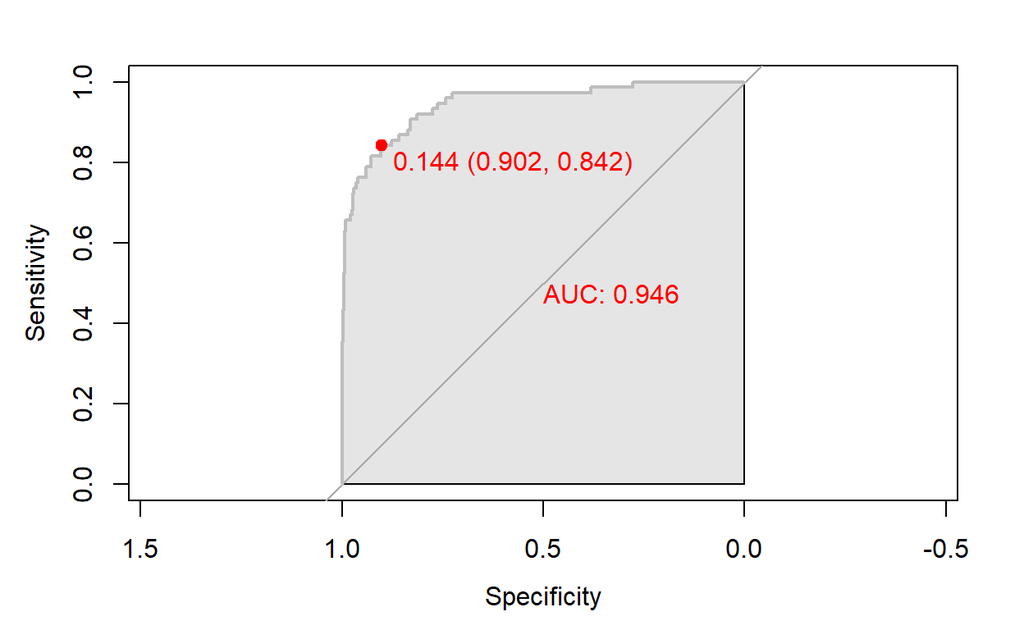

```r
# 함수 plot.roc() 이용
plot.roc(ridge.roc,
         col="gray",                                   # Line Color
         print.auc = TRUE,                             # AUC 출력 여부
         print.auc.col = "red",                        # AUC 글씨 색깔
         print.thres = TRUE,                           # Cutoff Value 출력 여부
         print.thres.pch = 19,                         # Cutoff Value를 표시하는 도형 모양
         print.thres.col = "red",                      # Cutoff Value를 표시하는 도형의 색깔
         auc.polygon = TRUE,                           # 곡선 아래 면적에 대한 여부
         auc.polygon.col = "gray90")                   # 곡선 아래 면적의 색깔
```

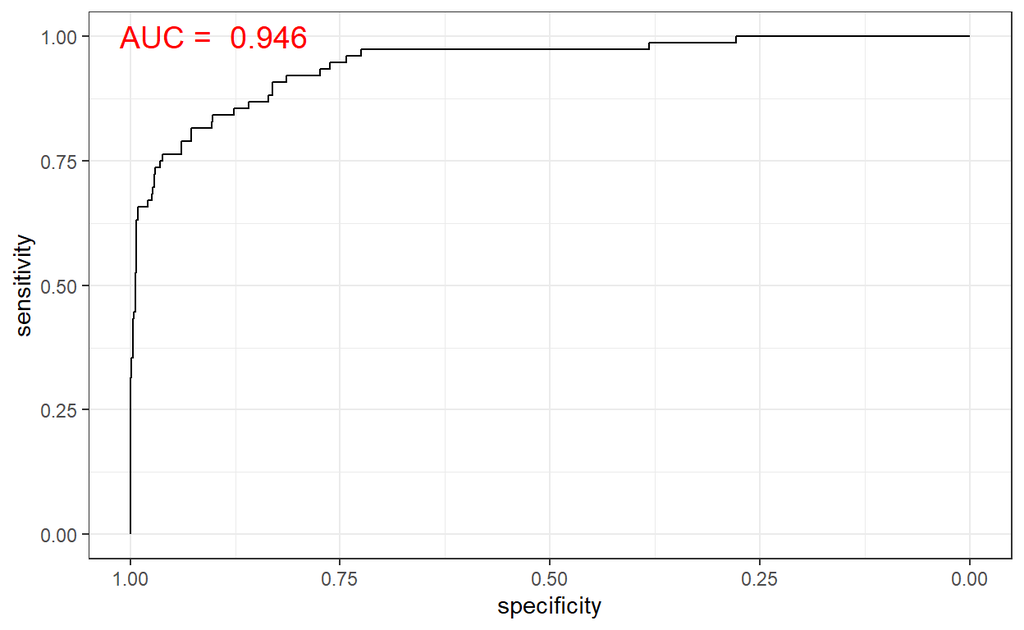

```r
# 함수 ggroc() 이용
ggroc(ridge.roc) +
annotate(geom = "text", x = 0.9, y = 1.0,
label = paste("AUC = ", auc),
size = 5,
color="red") +
theme_bw()
```

### **2) Package “Epi”**

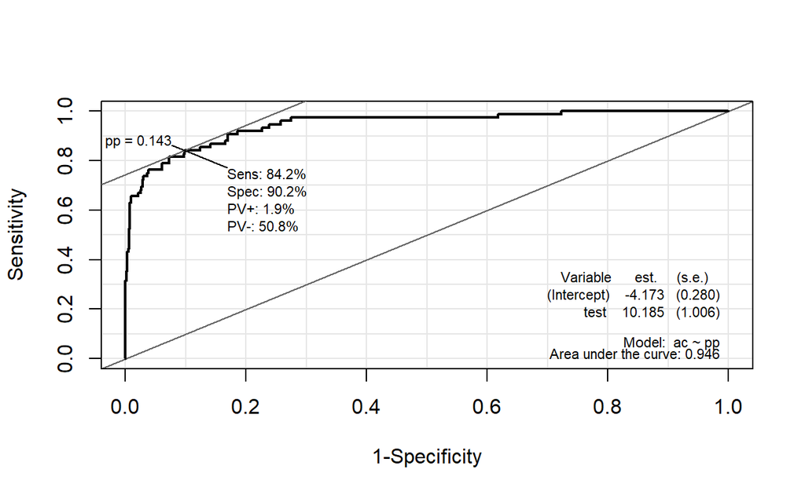

```r
pacman::p_load("Epi")
# install_version("etm", version = "1.1", repos = "http://cran.us.r-project.org")

ROC(pp, ac, plot = "ROC")                              # ROC(예측 확률, 실제 class)
```

### **3) Package “ROCR”**

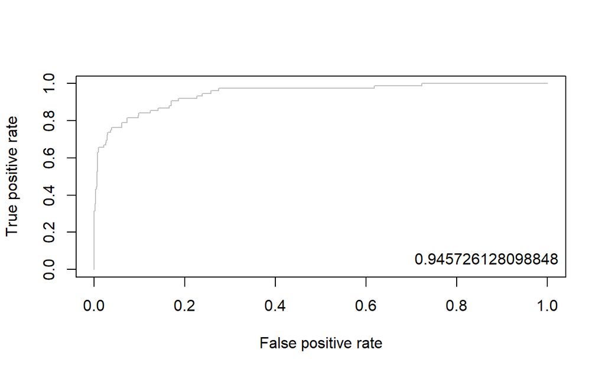

```r
pacman::p_load("ROCR")

ridge.pred <- prediction(pp, ac)                       # prediction(예측 확률, 실제 class)

ridge.perf <- performance(ridge.pred, "tpr", "fpr")    # performance(, "민감도", "1-특이도")
plot(ridge.perf, col = "gray")                         # ROC Curve

perf.auc   <- performance(ridge.pred, "auc")           # AUC
auc        <- attributes(perf.auc)$y.values
legend("bottomright", legend = auc, bty = "n")
```

## **6-3. 향상 차트**

### **1) Package “ROCR”**

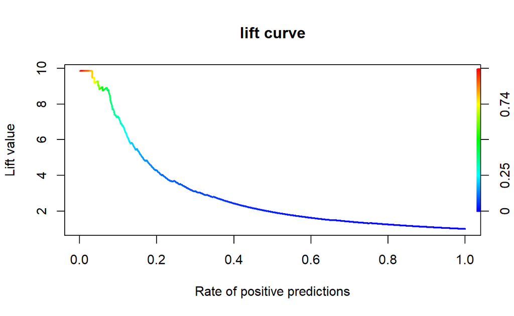

```r
ridge.perf <- performance(ridge.pred, "lift", "rpp")   # Lift Chart
plot(ridge.perf, main = "lift curve",
     colorize = T,                                     # Coloring according to cutoff
     lwd = 2)
```